# GSB518 Project

Kabir Wagle

2023-09-08

## Problem 1

*Topics:*

- *Basic probability and conditional probability calculations*
- *Independence*

You roll two fair 3 sided dice. Let X be the the number of 1’s rolled, and Y the difference between the two rolls.

a. What is the probability of X = 1?

$P(X = 1) = 2 * (0.33 * 0.66) = 0.4356$

b. Make a table of the distribution of X

| X | Distribution |
| --- | --- |
| 0 | 4/9 |
| 1 | 4/9 |
| 2 | 1/9 |

c. What is the probability of Y = 0?

$P(Y = 0) = 3 * (0.33 * 0.33) = 0.333$

d. Make a table of the distribution of Y

| Y | Distribution |
| --- | --- |
| 0 | 3/9 |
| 1 | 4/9 |
| 2 | 2/9 |

e. What is the probability that Y = 1 given that X = 1?

f. Make a table of the distribution of Y given X = 1

[output not shown]

g. Are the outcomes X and Y independent of each other? Show why or why not.

## Problem 2:

*Topics:*

- *Discrete random variables (pmf)*
- *Simulation process*
- *Simulation coding*

Suppose you want to determine how many penalty kicks it takes you to score a goal against a professional goalkeeper. The number of attempts X can be modeled by the geometric pdf:

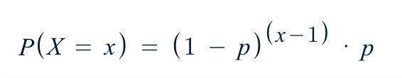

1. x is a discrete random variable that can take up values x = 1, 2,…, 10
2. p is the probability of making a penalty kick

[Wyscout](https://dataglossary.wyscout.com/xg/#:~:text=A%20penalty%20xG%20value%20is%20fixed%20to%200.76.&text=At%20the%20moment%20there%20are,an%20xG%20value%20of%20%3E%201.) defines Expected goals (xG) as predictive ML model used to assess the likelihood of scoring for every shot made in the game. The xG for a penalty kick is a fixed value of 0.76.

a. Sketch the pmf of X

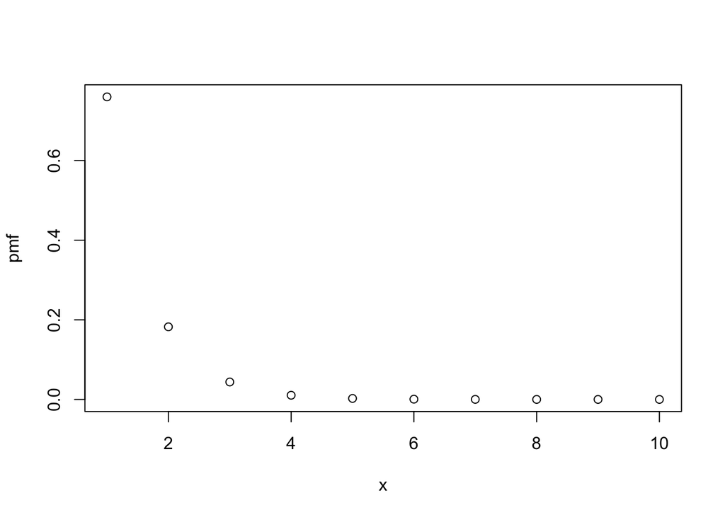

```r
x = 1:10
p = 0.76
pmf = (1 - p)^(x - 1) * p
plot(x, pmf)
```

b. Make a table of the distribution of X

```r
x = 1:10
p = 0.76
pmf = (1 - p)^(x - 1) * p
table = data.frame(cbind(x, pmf))
table
```

```
##     x          pmf
## 1   1 7.600000e-01
## 2   2 1.824000e-01
## 3   3 4.377600e-02
## 4   4 1.050624e-02
## 5   5 2.521498e-03
## 6   6 6.051594e-04
## 7   7 1.452383e-04
## 8   8 3.485718e-05
## 9   9 8.365724e-06
## 10 10 2.007774e-06
```

c. Calculate the probability of not scoring in your first three shots

$P(X > 3) = 1 - (0.76 + 0.1824 + 0.04377) = 0.01383$

d. Describe how you could simulate these results without actually having to take any penalty kicks

A great way to simulate the distribution of a discrete random variable is by using a spinner! In this case, you would have 10 sections of a spinner, each with a slice corresponding to the associated probabilities from part c. In order to simulate the results, spin the spinner many times and record the distribution of X.

Alternatively, you could set up the simulation to reflect the geometric probability of the scenario. Take a spinner with only two sections. One slice that covers 76% of the spinner and another that covers 24%. This represents each attempt to score. In order to simulate the results, spin the spinner until the outcome is a “success” and record the number of spins it took as the distribution of X (repeat many times as always).

e. **Coding required.** Code and run a simulation and use the results to approximate the distribution of X. Show that the distribution matches the results from part b.

```r
N_rep = 1000000 #number of reps
x = 1:10 #possible x values
p = 0.76 #probability of scoring
pmf = (1 - p)^(x - 1) * p #pmf
simulation = sample(x, N_rep, replace = T, pmf) #simulated values

table(simulation) / N_rep #Answers match part b.
```

```
## simulation
##        1        2        3        4        5        6        7        8
## 0.759321 0.182678 0.044146 0.010627 0.002411 0.000613 0.000160 0.000033
##        9       10
## 0.000009 0.000002
```

## Problem 3:

*Topics:*

- *Continuous random variables and probability density functions*
- *Percentiles, cumulative distribution functions, or quantile functions*

The number of intentional fouls in an NBA game at any given time t can be measured by the distribution X. Assume that X has the following PDF:

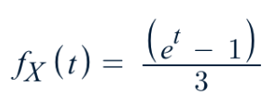

1. 0 < t < 1, Else = 0
2. t is measured in fractions of an hour (0.25 = 15 minutes)

a. Sketch the PDF of X

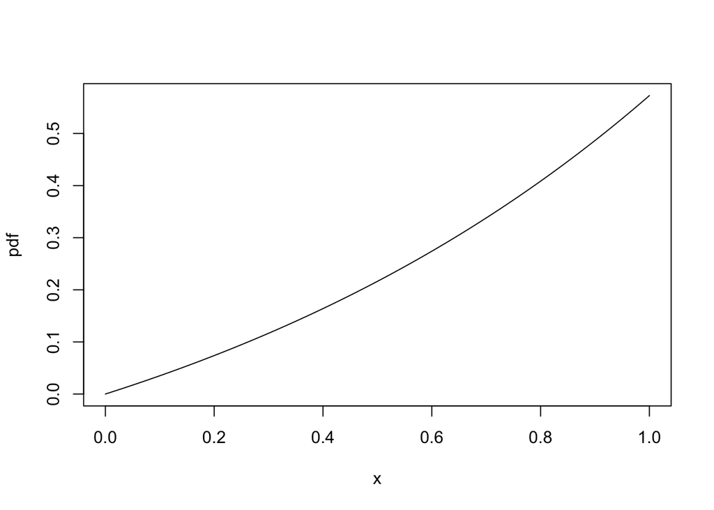

```r
pdf = function(x) {ifelse(x>=0 & x<=1, (exp(x) - 1)/3, 0)}
plot(pdf)
```

b. Estimate P(t < 0.50) using Geometry

$P(t < 0.50) = 1/2 * 0.50 * (e^.50 - 1) / 3 = 0.05406011$

$P(t < 1) = 1/2 * 1 * (e^1 - 1) / 3 = 0.2863803$

$0.05406011 / 0.2863803 = 0.1887704$

You can use the area of a triangle (1/2*base*height) to solve for the area under of the PDF. Because the area under the curve from 0:1 is not 1, we must divide the area to the left of t = 0.50 by the area to the left of t = 1.

c. Compute P(t < 0.50) using Integration and interpret what it means in context

```r
x = 0:1
f = function(x) {ifelse(x>=0 & x<=1, (exp(x) - 1)/3, 0)}
integrate(f, lower = 0, upper = 0.50)
```

```
## 0.04957376 with absolute error < 5.5e-16
```

```r
integrate(f, lower = 0, upper = 1)
```

```
## 0.2394273 with absolute error < 2.7e-15
```

```r
0.04957376 / 0.2394273
```

```
## [1] 0.2070514
```

Note that the values from part c do not exactly match with those from part b. That is because the PDF of X follows an exponential distribution, as opposed to a linear one.

d. Find an expression for the CDF of X.

This results in the following CDF:

$CDF_W(t) = (1/3)*e^t - (1/3)*t - (1/3)$

e. Compute and interpret CDF(0.50)

```r
cdf = function(x) {(1/3)*exp(x) - (1/3)*x - (1/3)}
cdf(0.50) / cdf(1)
```

```
## [1] 0.2070514
```

This means that approximately 20.7% of intentional fouls that happen in the NBA occur before halftime (30 minutes or t = 0.50).

f. The NBA has found an error in the model and the true CDF is actually just $(1/3)*x^2$ what is the associated quantile function?

The Quantile function can be found by taking the inverse of the CDF:

$p = (1/3) * t^2$

$3p = t^2$

$t = sqrt(3p$)

This means the Quantile function is the following:

$Q_W(t) = sqrt(3p)$

g. Find and interpret the 75th percentile of X.

```r
q = function(x) {(1/3) * x^2}
q(0.75) / q(1)
```

```
## [1] 0.5625
```

## Problem 4:

*Topics:*

- *Normal distributions or Bivariate Normal distributions*
- *Covariance or correlation*

Arsenal Football Club play in two major competitions the Premier League (PL) and the UEFA Champions League (UCL). Arsenal’s Expected Goals (XG) for a given game follows a normal distribution with mean 1.8 and SD 0.8 xg in the PL and a normal distribution with mean 2.0 and SD 1 xg in the UCL.

a. What is the probability that Arsenal have an xg of less than 1 in a PL match? What about in a UCL match? Interpret the results.

```r
pnorm(1, 1.8, 0.8)
```

```
## [1] 0.1586553
```

```r
pnorm(1, 2, 1)
```

```
## [1] 0.1586553
```

Using pnorm, there is on average a 15.9% probability that Arsenal will have an xg of less than 1 in both a PL match and a UCL match. This is because 1.0 xg is exactly one standard deviation away from the mean for both distributions.

b. What is the probability that Arsenal have a higher xg in a UCL match compared to a PL match?

$SD(UCL - PL) = sqrt(0.8^2 + 1^2) = 1.280625$

$E(UCL - PL) = 2.0 - 1.8 = 0.20$

$Z(UCL - PL) = (0.20 - 0)/1.28 = 0.15625$

```r
pnorm(0.15625, 0, 1)
```

```
## [1] 0.562082
```

c. Now assume the pair of xg distributions follow a Bivariate Normal distribution with correlation 0.850. Compute the probability that Arsenal will have a higher xg in a UCL match GIVEN that Arsenal have an xg of 2.8 in the PL.

$E(UCL|PL = 2.80) = 2 + 0.85 * 1((2.80-1.80)/0.80) = 3.0625$

$SD(UCL|PL = 2.80) = 1*sqrt(1 - 0.85^2) = 0.5266$

```r
pnorm(0.4984808 , 0, 1)
```

```
## [1] 0.6909274
```

## Problem 5

*Topics:*

- *Joint and conditional distributions*
- *Expected value*
- *Variance or standard deviation*

(Continued from Problem 1). You roll two fair 3 sided dice. Let X be the the number of 1’s rolled, and Y the difference between the two rolls.

a. Make a table of the Joint distribution of X and Y

| X | Y | **Probability** |
| --- | --- | --- |
| 0 | 0 | 2/9 |
| 0 | 1 | 2/9 |
| 0 | 2 | 0 |
| 1 | 0 | 0 |
| 1 | 1 | 2/9 |
| 1 | 2 | 2/9 |
| 2 | 0 | 1/9 |
| 2 | 1 | 0 |
| 2 | 2 | 0 |

b. What is the expected value of X? What about for Y?

$E(X) = (1 * 4/9) + (2 * 1/9) = 6/9 = 2/3$

$E(Y) = (1 * 4/9) + (2 * 2/9) = 8/9$

c. Make a table of the conditional Distribution of Y given X

| X | Y | P(Y\|X) |
| --- | --- | --- |
| 0 | 0 | 2/4 |
| 0 | 1 | 2/4 |
| 0 | 2 | 0 |
| 1 | 0 | 0 |
| 1 | 1 | 2/4 |
| 1 | 2 | 2/4 |
| 2 | 0 | 1/1 |
| 2 | 1 | 0 |
| 2 | 2 | 0 |

d. What is the expected value of Y GIVEN each value of X?

$E(Y | X = 0) = 1 * 2/4 = 2/4 = 1/2$

$E(Y | X = 1) = (1 * 2/4) + (2 * 2/4) = 6/4 = 3/2$

$E(Y | X = 2) = 0 * 1/1 = 0$

e. Compute each of the following:

1. E(XY)

   $E(XY) = (1 * 1 * 2/9) + (1 * 2 * 2/9) = 6/9 = 2/3$
2. SD(X)

   $E(X^2) = 1^2 * (4/9) + 2^2 * (1/9) = 8/9$

   $SD(X) = sqrt(E(X^2)−E(X)^2)$

   $SD(X) = sqrt(8/9 - (2/3)^2) = 0.6666667$
3. SD(Y)

   $E(Y^2) = 1^2 * (4/9) + 2^2 * (2/9) = 12/9 = 4/3$

   $SD(Y) = sqrt(E(Y^2)−E(Y)^2)$

   $SD(Y) = sqrt(4/3 - (8/9)^2) = 0.7370277$
4. Cov(X,Y)

   $Cov(X,Y)=E(XY)−E(X)∗E(Y)$

   $Cov(X,Y) = 2/3 - (2/3 * 8/9) = 0.07407407$
5. Corr(X,Y)

   $Corr(X,Y)=Cov(X,Y)/(SD(X)∗SD(Y))$

   $Corr(X,Y) = 0.0741 / (0.667 * 0.737) = 0.1507557$